# R Notebook

Pradeep Menon

## Notes:

### Facts

- Lifespan of a mosquito is around 10 days.
- Spray will impact the number of mosquitos.
- It is believed that hot and dry conditions are more favorable for West Nile virus than cold and wet.
- If there are more than 50 mosquitos then the record is split into new row.

### Intuition

- More the # of mosquitos => Better the probability for finding WNV
- Conditions of weather will be an important factor for prediction.

## Load Data and Util Files

```r
dim(testData)
```

```
[1] 116293     11
```

## Data Munging

### Training Data Enrichment

```r
### Collapse multi-records
trainDataFE <-
    trainData %>%
    group_by(Date, Street, Trap, Species, Latitude, Longitude) %>%
    summarise(NumMosquitos = sum(NumMosquitos),
              WnvConct = sum(WnvPresent)) %>%
    mutate(WnvPresent = ifelse(WnvConct > 1, 1, 0),
           Year = lubridate::year(Date),
           Week = lubridate::week(Date),
           Day = lubridate::day(Date),
           Month = lubridate::month(Date)

        ) %>%
    select(Date, Month, Year, Day, Week, Street, Trap, Species, Latitude,
           Longitude, NumMosquitos, WnvConct, WnvPresent) %>% data.frame()
### Identify Station
stations <- data.frame(c(1,2), c(41.995,41.786), c(-87.933,-87.752))
names(stations) <- c("Station","Latitude","Longitude")
locations <-
    trainDataFE %>% select(Latitude, Longitude) %>% distinct()

# allocate lat lon to nearest stations
locations$Station <- mapply(distanceCal, locations$Latitude,
                            locations$Longitude)

### Weather
### https://www.ncbi.nlm.nih.gov/pmc/articles/PMC4342965/
weather <-
    weather %>%
    select(Station, Date, Tmax, Tmin, Tavg, Depart, DewPoint, Heat,
                             Cool, PrecipTotal, ResultDir, ResultSpeed,
                             AvgSpeed, CodeSum) %>%
    data.frame()
## Combing train, weather and station
trainDataFE <-
    trainDataFE %>% inner_join(locations, c("Latitude", "Longitude")) %>%
    left_join(weather, c("Date", "Station"))
## Change Data Types
trainDataFE <-
    trainDataFE  %>%
    mutate(Tavg = as.numeric(Tavg),
           Tmax = as.numeric(Tmax),
           Tmin = as.numeric(Tmin),
           Heat = as.numeric(Heat),
           Cool = as.numeric(Cool),
           PrecipTotal = as.numeric(ifelse(PrecipTotal == 'T', '0.00',
                                           PrecipTotal)),
           AvgSpeed = as.numeric(AvgSpeed),
           Species = as.factor(Species),
           # Get the number weather variables
           CodeLen = length(strsplit(CodeSum, " ")[[1]])
    ) %>% mutate(CodeSum = as.factor(CodeSum))
```

```
NAs introduced by coercion
```

```r
# Remove NAs
trainDataFE[is.na(trainDataFE)] <- 0
```

```
invalid factor level, NA generated
```

```r
# Change CodeLen
trainDataFE$CodeLen <- ifelse(is.na(trainDataFE$CodeSum) == 1,
                              0, trainDataFE$CodeLen)
# Reset Levels
trainDataFE$Species <- droplevels(trainDataFE$Species)
## Export Data for EDA
#write.csv(x = trainDataFE, file = "trainDataFE.csv", row.names = FALSE)
```

### Test Data Enrichment

```r
testDataFE <-
    testData %>%
    mutate(Year = lubridate::year(Date),
           Day = lubridate::day(Date),
           Month = lubridate::month(Date),
           Week = lubridate::week(Date)

        ) %>%
    select(Date, Month, Year, Week, Day, Street, Trap, Species,
           Latitude, Longitude) %>% data.frame()
# Join with location and station data
locations <-
    testDataFE %>% select(Latitude, Longitude) %>% distinct()

locations$Station <- mapply(distanceCal, locations$Latitude,
                            locations$Longitude)

## Combing test, weather and station
testDataFE <-
    testDataFE %>% inner_join(locations, c("Latitude", "Longitude")) %>%
    left_join(weather, c("Date", "Station"))
## Change UNSPECIFIED CULEX to CULEX ERRATICUS
testDataFE <-
    testDataFE %>%
    mutate(Species = ifelse(Species == "UNSPECIFIED CULEX",
                            "CULEX ERRATICUS", Species))
## Change Data Types
testDataFE <-
    testDataFE %>%
    mutate(Tavg = as.numeric(Tavg),
           Tmax = as.numeric(Tmax),
           Tmin = as.numeric(Tmin),
           Heat = as.numeric(Heat),
           Cool = as.numeric(Cool),
           PrecipTotal = as.numeric(ifelse(PrecipTotal == 'T', '0.00',
                                           PrecipTotal)),
           AvgSpeed = as.numeric(AvgSpeed),
           Species = as.factor(Species),
           # Get the number weather variables
           CodeLen = length(strsplit(CodeSum, " ")[[1]])
    ) %>% mutate(CodeSum = as.factor(CodeSum))
# Remove NAs
testDataFE[is.na(testDataFE)] <- 0
```

```
invalid factor level, NA generated
```

```r
# Change CodeLen
testDataFE$CodeLen <- ifelse(is.na(testDataFE$CodeSum) == 1,
                              0, testDataFE$CodeLen)
# Reset levels
testDataFE$Species <- droplevels(testDataFE$Species)
# Export Data
write.csv(x = testDataFE, file = "testDataFE.csv", row.names = FALSE)
```

## Data Exploration

- We employ following strategy:
  - Count Analysis => To understand the distribution of data points wrt target (WnvPresent)
  - Statistical and Correlation Analysis between numerical variables.
  - Determining which variables impact WnvPresent.

### Count Analysis

#### Count by Target

- Observations:
  - This is an unbalanced set. 99.43% of records have no WNV virus.
  - No data in 2009 for WnvPresent.

```r
CountAnalysis(data = trainDataFE, WnvPresent)
```

| WnvPresent | count | percent |
| --- | --- | --- |
| 0 | 8426 | 99.43 |
| 1 | 48 | 0.57 |

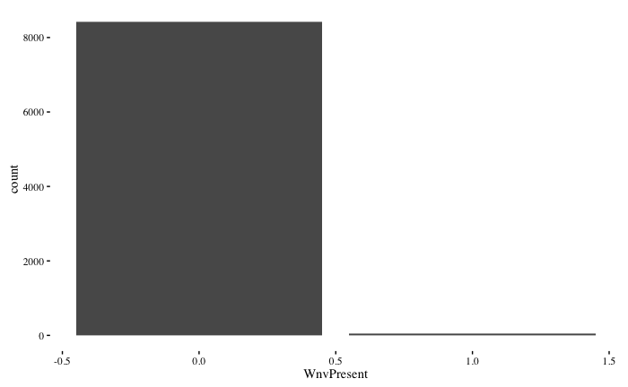

```r
ggplot(data = trainDataFE, aes(WnvPresent)) + geom_bar() + theme_tufte()
```

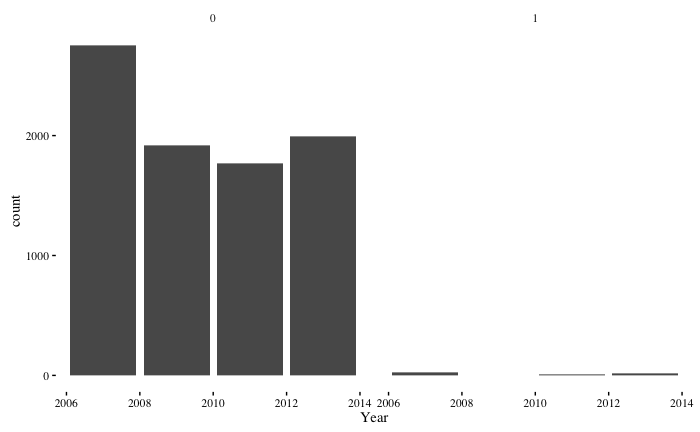

```r
ggplot(data = trainDataFE, aes(Year)) + geom_bar() + theme_tufte() +
    facet_wrap(~ WnvPresent)
```

### Correlation Analysis

#### Multi-Collinearity

- In regression, we look at the correlations between one or more input variables, or factors, and a response.
- In regression, “multicollinearity” refers to predictors that are correlated with other predictors.
- Multicollinearity occurs when your model includes multiple factors that are correlated not just to your response variable, but also to each other. In other words, it results when you have factors that are a bit redundant.
- We will use R to detect multicollinearity visually. The strategy we will employ is the following:
  - Check for correlations over all the attributes.
  - Check for correlations within the feature groups.
- High Correlation (> 0.8) found between:
  - Tavg, Tmax and Cool
  - Tavg, DewPoint, Tmin and Cool
  - ResultSpeed and AvgSpeed
- Following variables from weather can be chosen for further analysis:
  - NumMosquitos, Tavg, PrecipTotal, AvgSpeed and Heat

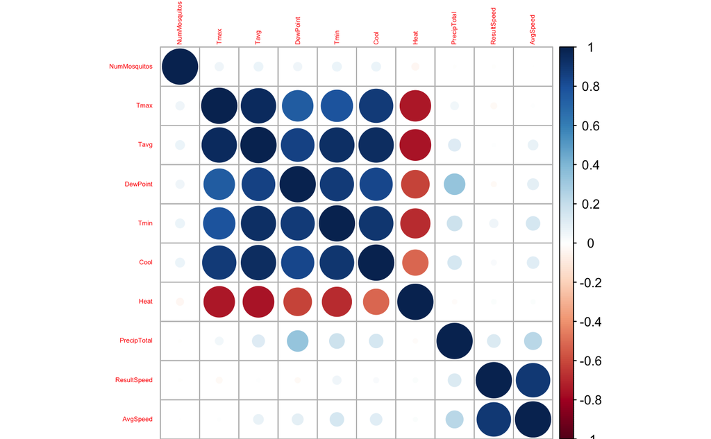

```
[[1]]
              NumMosquitos         Tmax         Tavg    DewPoint        Tmin        Cool        Heat
NumMosquitos  1.0000000000  0.054708075  0.062672255  0.05372462  0.06394515  0.06326607 -0.03968284
Tmax          0.0547080751  1.000000000  0.950308141  0.74868256  0.78777676  0.88909164 -0.74679716
Tavg          0.0626722548  0.950308141  1.000000000  0.85837737  0.93933111  0.94891574 -0.75829990
DewPoint      0.0537246228  0.748682559  0.858377371  1.00000000  0.88383184  0.83377242 -0.61114677
Tmin          0.0639451548  0.787776765  0.939331114  0.88383184  1.00000000  0.90537562 -0.68330870
Cool          0.0632660742  0.889091636  0.948915744  0.83377242  0.90537562  1.00000000 -0.51386714
Heat         -0.0396828375 -0.746797156 -0.758299904 -0.61114677 -0.68330870 -0.51386714  1.00000000
PrecipTotal  -0.0044604050  0.048450714  0.116174301  0.33926371  0.17319391  0.14537901 -0.01549456
ResultSpeed  -0.0063456197 -0.028186304  0.009032602 -0.02035991  0.05503660  0.02009724  0.01696421
AvgSpeed     -0.0001390903  0.008524073  0.075887988  0.09463650  0.14584013  0.10656850  0.01385168
              PrecipTotal  ResultSpeed      AvgSpeed
NumMosquitos -0.004460405 -0.006345620 -0.0001390903
Tmax          0.048450714 -0.028186304  0.0085240732
Tavg          0.116174301  0.009032602  0.0758879880
DewPoint      0.339263706 -0.020359906  0.0946365045
Tmin          0.173193912  0.055036600  0.1458401346
Cool          0.145379014  0.020097238  0.1065684968
Heat         -0.015494556  0.016964212  0.0138516850
PrecipTotal   1.000000000  0.129126897  0.2311787972
ResultSpeed   0.129126897  1.000000000  0.8992418817
AvgSpeed      0.231178797  0.899241882  1.0000000000

[[2]]
              NumMosquitos         Tmax        Tmin         Tavg    DewPoint  PrecipTotal        Heat
NumMosquitos  1.0000000000  0.054708075  0.06394515  0.062672255  0.05372462 -0.004460405 -0.03968284
Tmax          0.0547080751  1.000000000  0.78777676  0.950308141  0.74868256  0.048450714 -0.74679716
Tmin          0.0639451548  0.787776765  1.00000000  0.939331114  0.88383184  0.173193912 -0.68330870
Tavg          0.0626722548  0.950308141  0.93933111  1.000000000  0.85837737  0.116174301 -0.75829990
DewPoint      0.0537246228  0.748682559  0.88383184  0.858377371  1.00000000  0.339263706 -0.61114677
PrecipTotal  -0.0044604050  0.048450714  0.17319391  0.116174301  0.33926371  1.000000000 -0.01549456
Heat         -0.0396828375 -0.746797156 -0.68330870 -0.758299904 -0.61114677 -0.015494556  1.00000000
Cool          0.0632660742  0.889091636  0.90537562  0.948915744  0.83377242  0.145379014 -0.51386714
ResultSpeed  -0.0063456197 -0.028186304  0.05503660  0.009032602 -0.02035991  0.129126897  0.01696421
AvgSpeed     -0.0001390903  0.008524073  0.14584013  0.075887988  0.09463650  0.231178797  0.01385168
                    Cool  ResultSpeed      AvgSpeed
NumMosquitos  0.06326607 -0.006345620 -0.0001390903
Tmax          0.88909164 -0.028186304  0.0085240732
Tmin          0.90537562  0.055036600  0.1458401346
Tavg          0.94891574  0.009032602  0.0758879880
DewPoint      0.83377242 -0.020359906  0.0946365045
PrecipTotal   0.14537901  0.129126897  0.2311787972
Heat         -0.51386714  0.016964212  0.0138516850
Cool          1.00000000  0.020097238  0.1065684968
ResultSpeed   0.02009724  1.000000000  0.8992418817
AvgSpeed      0.10656850  0.899241882  1.0000000000
```

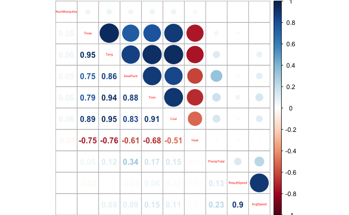

```r
# Weather Correlations
varList <- c("NumMosquitos", "Tmax", "Tmin",
                                         "Tavg", "DewPoint", "PrecipTotal",
                                         "Heat", "Cool", "ResultSpeed",
                                         "AvgSpeed")
getCorr(trainDataFE, varList)
```

### Variability Analysis

#### # of Mosquitos

- Observations:
  - Data is not evenly distributed.
  - Cross-Validation or Boosting needs to be applied.
  - WnvPresent influencers:
    - Months 7, 8, 9 have more variablity and shows WNV Present
    - Places near Station 2 has more distribution WNV
    - WNV found only in 3 species. Predominantly in CULEX PIPIENS
    - WNV seems to be predominant when there are multiple code sums and with BR

```r
# Overall
getStats(trainDataFE, var = NumMosquitos) # get general distribution of Num Mosquitos
```

|  | Value |
| --- | --- |
| count | 8474.00000 |
| na | 0.00000 |
| min | 1.00000 |
| max | 2532.00000 |
| mean | 15.93486 |
| median | 4.00000 |
| range | 2531.00000 |
| sd | 75.08907 |
| variance | 5638.36918 |
| skewness | 19.48579 |

[output cut: 1 more lines]

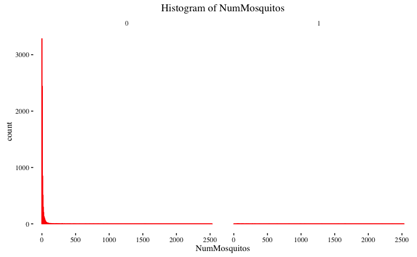

```r
plotHist(data = trainDataFE, bin_width = 5, x = NumMosquitos) + facet_wrap(~ WnvPresent)
```

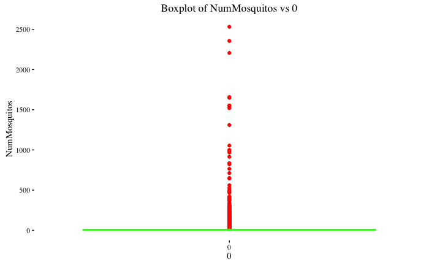

```r
plotBox(data = trainDataFE, x = 0, y = NumMosquitos)
```

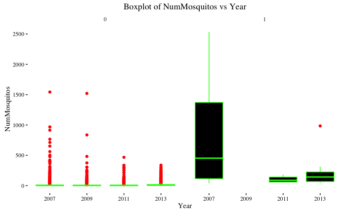

```r
# Year
plotBox(data = trainDataFE, x = Year, y = NumMosquitos) +
    facet_wrap(~ WnvPresent)
```

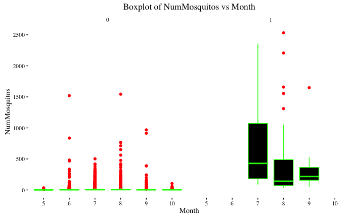

```r
# Month
plotBox(data = trainDataFE, x = Month, y = NumMosquitos) +
    facet_wrap(~ WnvPresent)
```

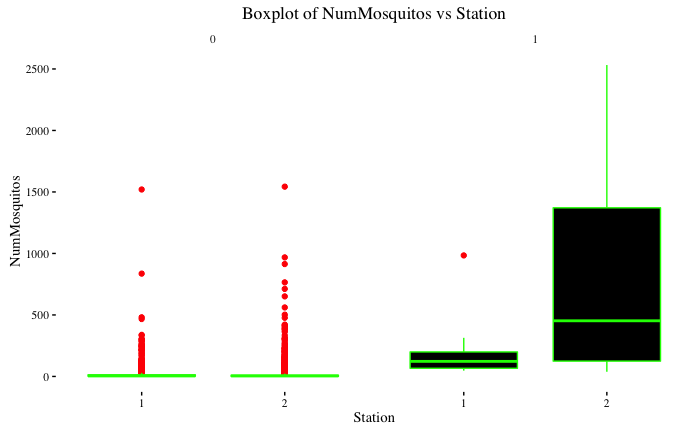

```r
# Station
plotBox(data = trainDataFE, x = Station, y = NumMosquitos) +
    facet_wrap(~ WnvPresent)
```

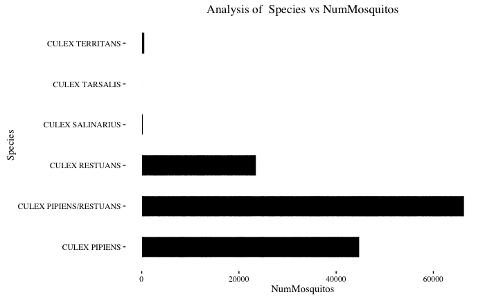

```r
# Species
# overall
plotBar(data = trainDataFE, x = Species, y = NumMosquitos) + coord_flip()
```

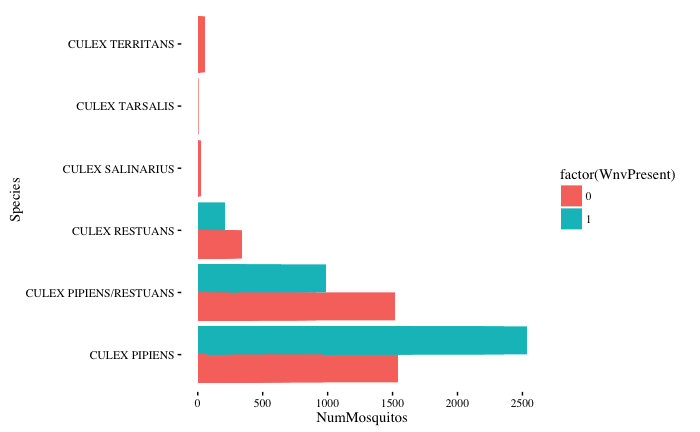

```r
# distribution by target
ggplot(data = trainDataFE, aes(Species, NumMosquitos)) +
    geom_bar(aes(fill = factor(WnvPresent)),
                 stat = "identity", position = "dodge") + coord_flip() + theme_tufte()
```

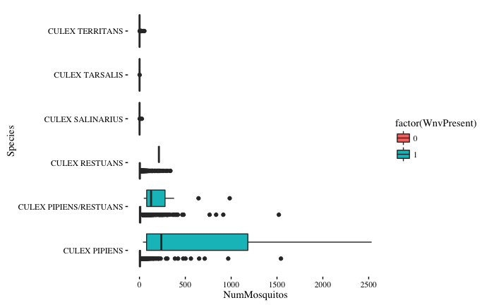

```r
# variability
ggplot(data = trainDataFE, aes(Species, NumMosquitos))  +
    geom_boxplot(aes(fill = factor(WnvPresent))) + coord_flip() + theme_tufte()
```

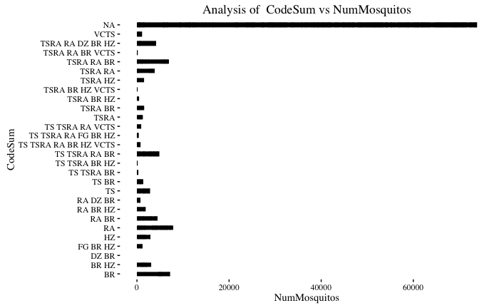

```r
# Code Sum
plotBar(data = trainDataFE, x = CodeSum, y = NumMosquitos) + coord_flip()
```

[figure not shown]

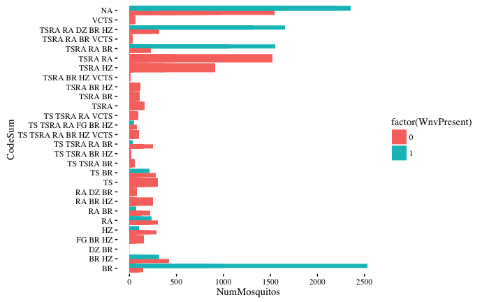

```r
# distribution by target
ggplot(data = trainDataFE, aes(CodeSum, NumMosquitos)) +
    geom_bar(aes(fill = factor(WnvPresent)),
                 stat = "identity", position = "dodge") + coord_flip() + theme_tufte()
```

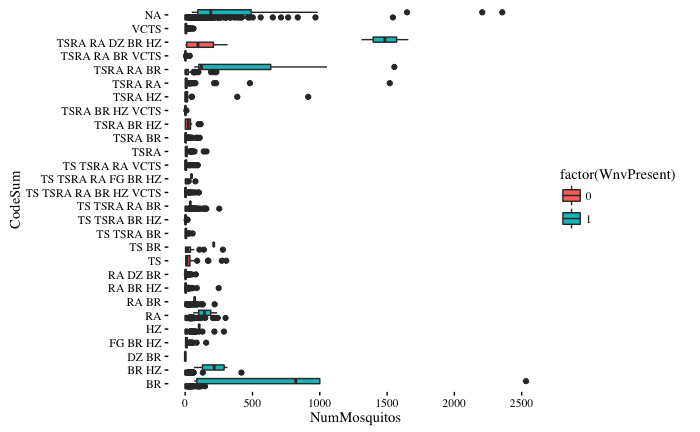

```r
# variability
ggplot(data = trainDataFE, aes(CodeSum, NumMosquitos))  +
    geom_boxplot(aes(fill = factor(WnvPresent))) + coord_flip() + theme_tufte()
```

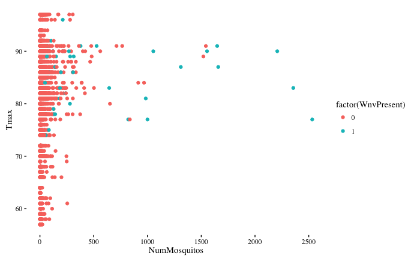

```r
# scatter plots
# Num of Mosquitos vs Tmax
ggplot(data = trainDataFE, aes(NumMosquitos, Tmax))  +
    geom_point(aes(color = factor(WnvPresent))) + theme_tufte()
```

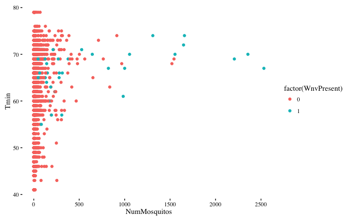

```r
# Num of Mosquitos vs Tmin
ggplot(data = trainDataFE, aes(NumMosquitos, Tmin))  +
    geom_point(aes(color = factor(WnvPresent))) + theme_tufte()
```

#### Avg Temperature vs WnvPresent

```r
# Overall
getStats(trainDataFE, var = Tavg)
```

|  | Value |
| --- | --- |
| count | 8474.0000000 |
| na | 0.0000000 |
| min | 50.0000000 |
| max | 87.0000000 |
| mean | 72.6485721 |
| median | 74.0000000 |
| range | 37.0000000 |
| sd | 7.6366148 |
| variance | 58.3178860 |
| skewness | -0.8721583 |

[output cut: 1 more lines]

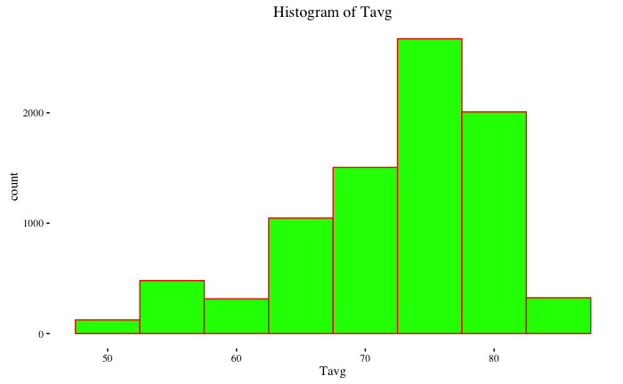

```r
plotHist(data = trainDataFE, bin_width = 5,  x = Tavg)
```

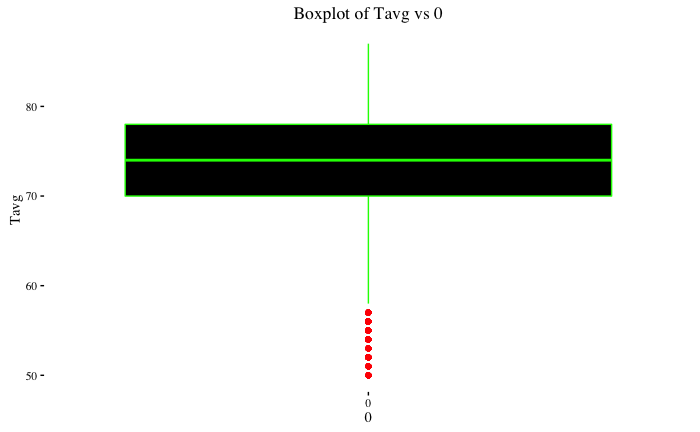

```r
plotBox(data = trainDataFE, x = 0, y = Tavg)
```

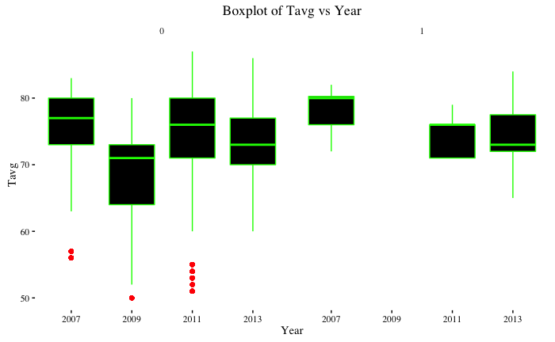

```r
# Year
plotBox(data = trainDataFE, x = Year, y = Tavg) +
    facet_wrap(~ WnvPresent)
```

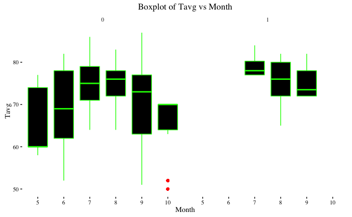

```r
# Month
plotBox(data = trainDataFE, x = Month, y = Tavg) +
    facet_wrap(~ WnvPresent)
```

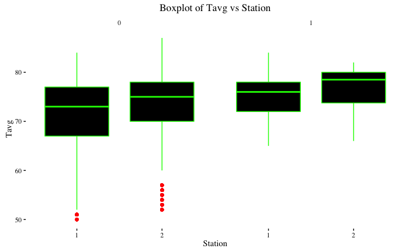

```r
# Station
plotBox(data = trainDataFE, x = Station, y = Tavg) +
    facet_wrap(~ WnvPresent)
```

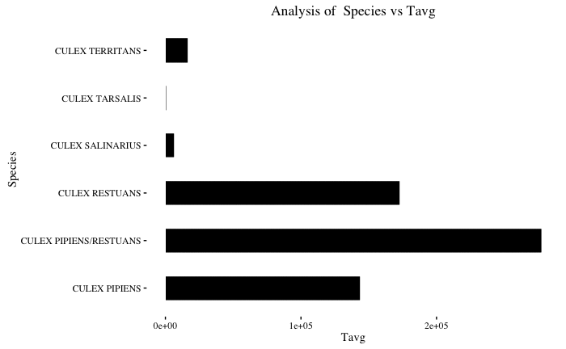

```r
# Species
# overall
plotBar(data = trainDataFE, x = Species, y = Tavg) + coord_flip()
```

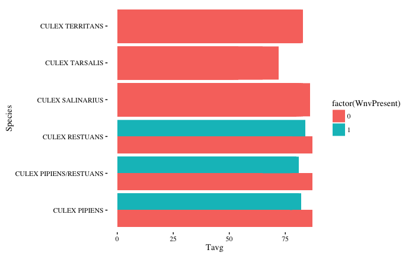

```r
# distribution by target
ggplot(data = trainDataFE, aes(Species, Tavg)) +
    geom_bar(aes(fill = factor(WnvPresent)),
                 stat = "identity", position = "dodge") + coord_flip() + theme_tufte()
```

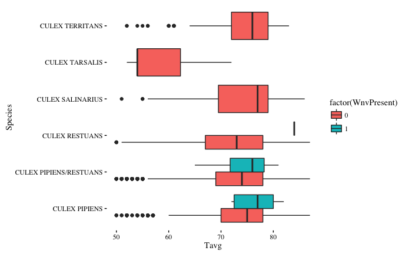

```r
# variability
ggplot(data = trainDataFE, aes(Species, Tavg))  +
    geom_boxplot(aes(fill = factor(WnvPresent))) + coord_flip() + theme_tufte()
```

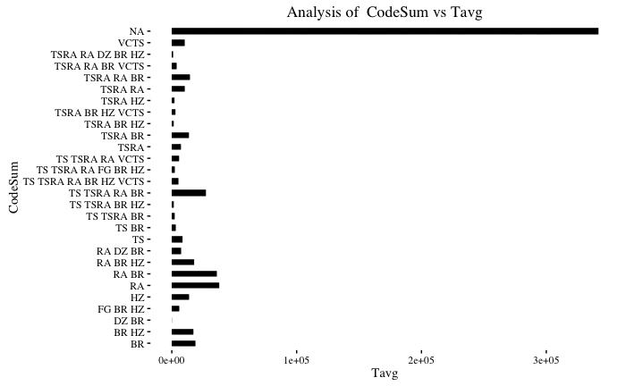

```r
# Code Sum
plotBar(data = trainDataFE, x = CodeSum, y = Tavg) + coord_flip()
```

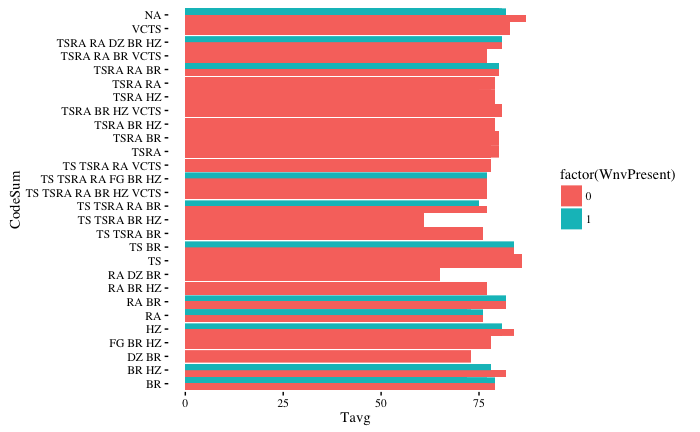

```r
# distribution by target
ggplot(data = trainDataFE, aes(CodeSum, Tavg)) +
    geom_bar(aes(fill = factor(WnvPresent)),
                 stat = "identity", position = "dodge") + coord_flip() + theme_tufte()
```

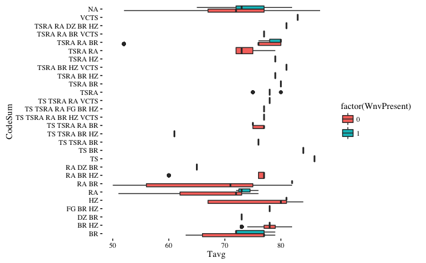

```r
# variability
ggplot(data = trainDataFE, aes(CodeSum, Tavg))  +
    geom_boxplot(aes(fill = factor(WnvPresent))) + coord_flip() + theme_tufte()
```